# Koel Dutta Chowdhury

Skip to content

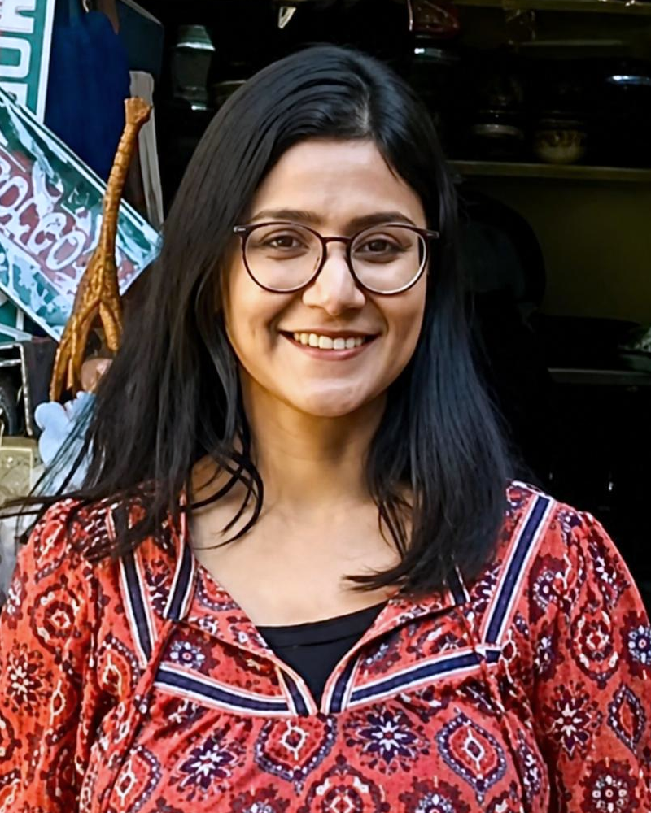

Postdoctoral Researcher  
[University of Technology Nuremberg](https://www.utn.de/en/)

[Scholar](https://scholar.google.com/citations?user=t5TOnGkAAAAJ)[GitHub](https://github.com/koeldc)[X](https://twitter.com/KoelDC)Email

# Koel Dutta Chowdhury

I am a **Postdoctoral Researcher** in the Natural Language Learning & Generation (NLLG) Lab at [TU Nürnberg](https://www.utn.de/en/).

My research focuses on **multilingual language models** and **trustworthy AI**. I study how models represent and use knowledge and linguistic information, and how to evaluate their behaviour reliably.

My work examines how models combine internal knowledge with external evidence, how multilingual representations relate to social bias, and how confounds affect model evaluation. I use behavioural analysis and interpretability methods to connect what models encode with how they behave, and to understand when evaluation results can be misleading.

I hold a PhD in Computational Linguistics from Saarland University, where I studied how non-native and non-standard language varieties are misrepresented in NLP. Prior to that, I studied computer science and mathematics and worked on multimodal neural machine translation.

Off the pageOutside research, I enjoy travelling and old comics, especially [Astérix](https://papercutz.com/series/asterix/) and *[The Timid Soul](https://en.wikipedia.org/wiki/The_Timid_Soul)*. Recommendations welcome: training data attribution and provenance, especially their implications for fairness, or old comics. Happy to talk about either!

## News

1. Our new preprint, FondueQA, asks when models fill gaps in retrieved evidence with internal knowledge.

   October 2026
2. Presenting A Clever Hans Effect (Findings) and Tracing Stereotypes (main conference) at **[EMNLP 2026](https://2026.emnlp.org/)**.

   October 2026
3. Recognised as an **Outstanding Reviewer at [EMNLP 2026](https://2026.emnlp.org/)**.

   2026
4. I contributed to the Last Translation Benchmark, a community effort to collect challenging translation examples.

   September 2026
5. Our new preprint, Cultivar, tests translation evaluation for contamination and sensitivity to locale.

   August 2026
6. I joined **UTN** as a postdoctoral researcher in NLP.

   July 2026
7. Co-organised [MeLLM](https://www.mellm.org/), the first Workshop on Multilinguality in the Era of Large Language Models, at ACL 2026.

   July 2026
8. Received compute grants through Tinker Research Grants from Thinking Machines Lab and a Cohere Labs Catalyst Grant.

   2026
9. [Grounding or Guessing?](https://arxiv.org/abs/2510.18439) at ICLR 2026; [When Flores Bloomz Wrong](https://aclanthology.org/2026.eacl-short.26/) at EACL 2026; and [PETra](https://aclanthology.org/2026.lrec-1.689/) at LREC 2026.

   2026
10. [TenseLoC](https://aclanthology.org/2025.mrl-main.17/) received the Best Paper Award at MRL 2025.

    November 2025